# MATH333 HW1

#### Exercise 1

Done :D

#### Exercise 2

Installed `xts` and `zoo` packages.

```r
library(xts)
library(zoo)
```

#### Exercise 3

Installed package `astsa`

```r
library(astsa)
```

#### Exercise 4

```r
(1:20/10) %% 1
```

```
##  [1] 0.1 0.2 0.3 0.4 0.5 0.6 0.7 0.8 0.9 0.0 0.1 0.2 0.3 0.4 0.5 0.6 0.7 0.8 0.9
## [20] 0.0
```

This generates the sequence of numbers 1 through 20, divides each by 10, then does modulus division on each by 1.

#### Exercise 5

Verifying:
$$1/i = -i$$

```r
1/1i
```

```
## [1] 0-1i
```

#### Exercise 6

Verifying:
$$e^{i\pi} = -1$$

```r
exp(1i*pi)
```

```
## [1] -1+0i
```

#### Exercise 7

```r
cos(pi*1:4/2)
```

```
## [1]  6.123032e-17 -1.000000e+00 -1.836910e-16  1.000000e+00
```

#### Exercise 8

`0 = x = y` actually generates an error, while the following assigns 0 to both `x` and `y`.

```r
0 -> x -> y; x; y
```

```
## [1] 0
```

```
## [1] 0
```

#### Exercise 9

```r
y = c(2,4); z = c(8,3,2)
```

If we try to add `y` to `z`, we see R’s recycling rule for arithmetic. We expect the vector (10, 7, 4) because of the mismatched sizes of the vectors. R adds the first element of y to z.

```r
y + z
```

```
## [1] 10  7  4
```

#### Exercise 10

Writing `cpg` data file to “zzz.txt”.

```r
#help(cpg)
write(cpg, file="zzz.txt", ncolumns = 1)
```

#### Exercise 11

Done!

#### Exercise 12

Scanning the data in the file “zzz.txt”.

```r
(dummy = scan("zzz.txt"))
```

```
##  [1] 2.13e+05 2.95e+05 2.60e+05 1.75e+05 1.60e+05 7.10e+04 6.00e+04 3.00e+04
##  [9] 3.60e+04 9.00e+03 7.00e+03 4.00e+03 2.00e+03 9.50e+02 8.65e+02 2.59e+02
## [17] 1.03e+02 6.29e+01 2.45e+01 1.25e+01 6.41e+00 2.68e+00 1.57e+00 1.38e+00
## [25] 6.70e-01 5.30e-01 4.20e-01 2.70e-01 7.00e-02
```

#### Exercise 13

Creating sequence `a` with odd numbers and `b` with even numbers. Then, column-binding the two into an object `x`.

```r
a = seq(1,10, by=2)
b = seq(2, 10, by=2)
x = cbind(a,b)
x
```

```
##      a  b
## [1,] 1  2
## [2,] 3  4
## [3,] 5  6
## [4,] 7  8
## [5,] 9 10
```

```r
x[,1]
```

```
## [1] 1 3 5 7 9
```

#### Exercise 14

Generating 100 standard normals and drawing a boxplot of the results.

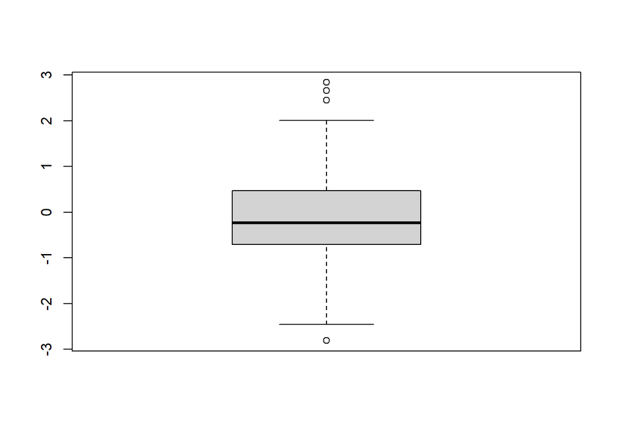

```r
options(digits=3)
set.seed(911)
boxplot(rnorm(100))
```

#### Exercise 15

Writing a function that takes two numbers, `x` and `y` and returns `x` raised to the power of `y`.

```r
pwr <- function(x,y){x^y}
pwr(5,2)
```

```
## [1] 25
```

#### Exercise 16

Add red horizontal and vertical lines to plot.

```r
set.seed(666)
x = rnorm(10)
y = 1 + 2*x + rnorm(10)
summary(fit <- lm(y~x))
```

```
##
## Call:
## lm(formula = y ~ x)
##
## Residuals:
##     Min      1Q  Median      3Q     Max
## -1.2280 -1.0130  0.0594  0.6040  2.3248
##
## Coefficients:
##             Estimate Std. Error t value Pr(>|t|)
## (Intercept)    1.068      0.374    2.85  0.02131 *
## x              1.678      0.265    6.33  0.00023 ***
## ---
## Signif. codes:  0 '***' 0.001 '**' 0.01 '*' 0.05 '.' 0.1 ' ' 1
##
## Residual standard error: 1.18 on 8 degrees of freedom
## Multiple R-squared:  0.834,  Adjusted R-squared:  0.813
## F-statistic: 40.1 on 1 and 8 DF,  p-value: 0.000225
```

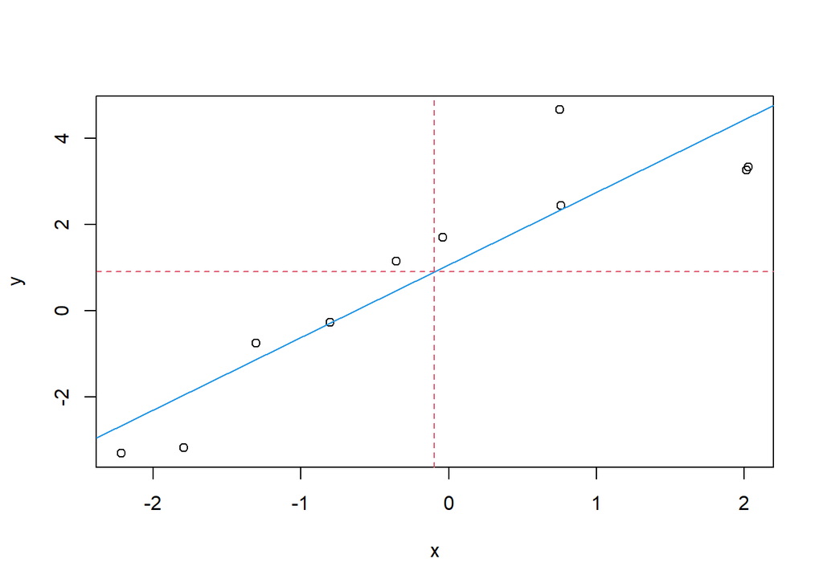

```r
plot(x,y)
abline(fit, col=4)

abline(h=mean(y), col=2, lty=2)
abline(v=mean(x), col=2, lty=2)
```

#### Exercise 17

Run the previous example of mortality on poulltion without first making a data frame.

```r
part4 <- lag(part, -4)
summary(fit <- lm(cmort~ part + part4, na.action=NULL))
```

```
##
## Call:
## lm(formula = cmort ~ part + part4, na.action = NULL)
##
## Residuals:
##    Min     1Q Median     3Q    Max
## -21.61  -6.33  -0.63   5.38  36.25
##
## Coefficients: (1 not defined because of singularities)
##             Estimate Std. Error t value Pr(>|t|)
## (Intercept)  74.7986     1.3094    57.1   <2e-16 ***
## part          0.2932     0.0263    11.1   <2e-16 ***
## part4             NA         NA      NA       NA
## ---
## Signif. codes:  0 '***' 0.001 '**' 0.01 '*' 0.05 '.' 0.1 ' ' 1
##
## Residual standard error: 8.97 on 506 degrees of freedom
## Multiple R-squared:  0.197,  Adjusted R-squared:  0.195
## F-statistic:  124 on 1 and 506 DF,  p-value: <2e-16
```

#### Exercise 18

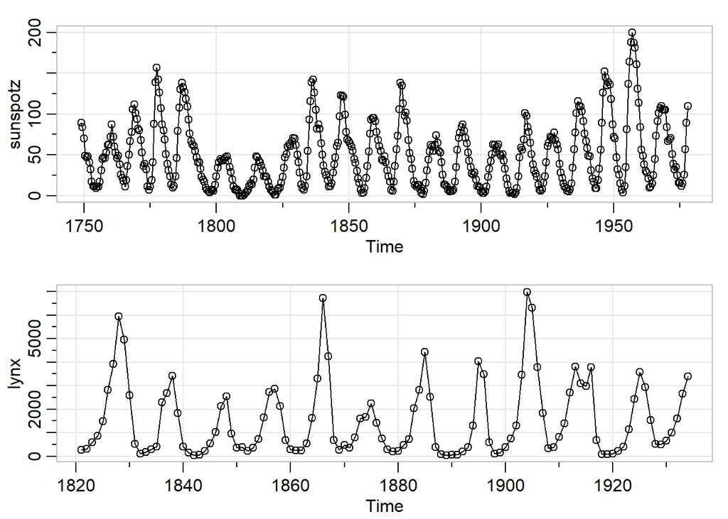

```r
par(mfrow=c(2,1))
tsplot(sunspotz, type="o")
tsplot(lynx, type="o")
```